# IDG-DREAM Round 2 Bayes Factor Analysis - all predictions

06 June, 2019

Round 2 of the IDG-DREAM Challenge gave participants two opportunities to predict 394 Kd values between 25 compounds and 207 kinases. There are two subchallenges in this round that participants can win via:

Sub-challenge 1: The top-performing teams will be selected based on the bootstrapped Spearman correlation of the predictions to the test dataset. Teams that have a Bayes Factor of less than 3 are tied. The tiebreaking metric to select the top performer will be the submission with the highest average AUC score.

Sub-challenge 2: The top-performing teams will be selected based on the bootstrapped RMSE of the predictions to the test dataset. Teams that have a Bayes Factor of less than 3 are tied. The tiebreaking metric to select the top performer will be the submission with the highest average AUC score.

In addition, participants/teams needed to submit a Dockerized model, writeup, and methods survey to qualified. Participants that could not fulfill this criteria were disqualified.

Here, we are only looking all results regardles of qualification.

### SC1 - SPEARMAN

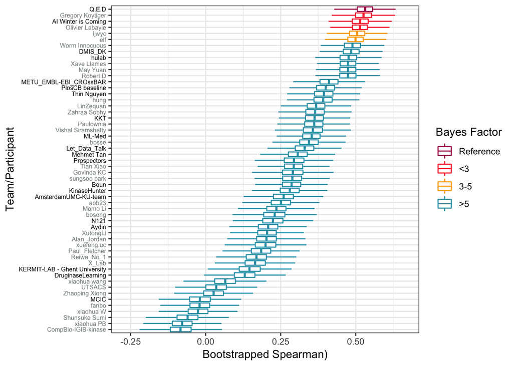

### SC2 - RMSE

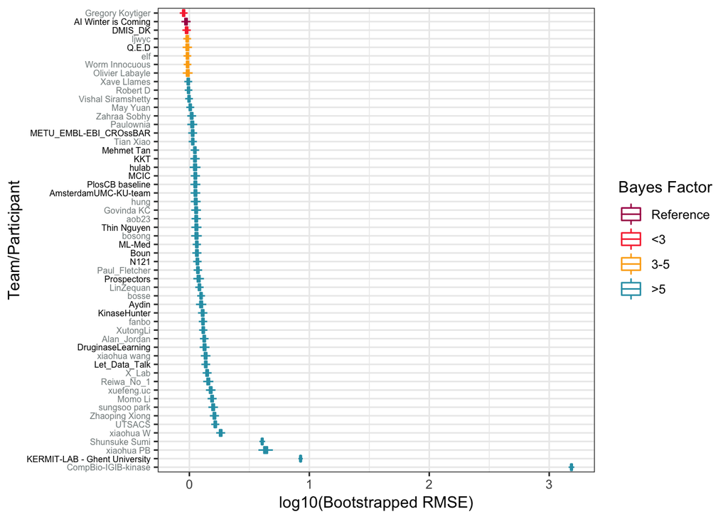

Now, let’s reanalyze the above plots, but using the baseline as the reference for the Bayes factor calculation.

### SC1 - SPEARMAN

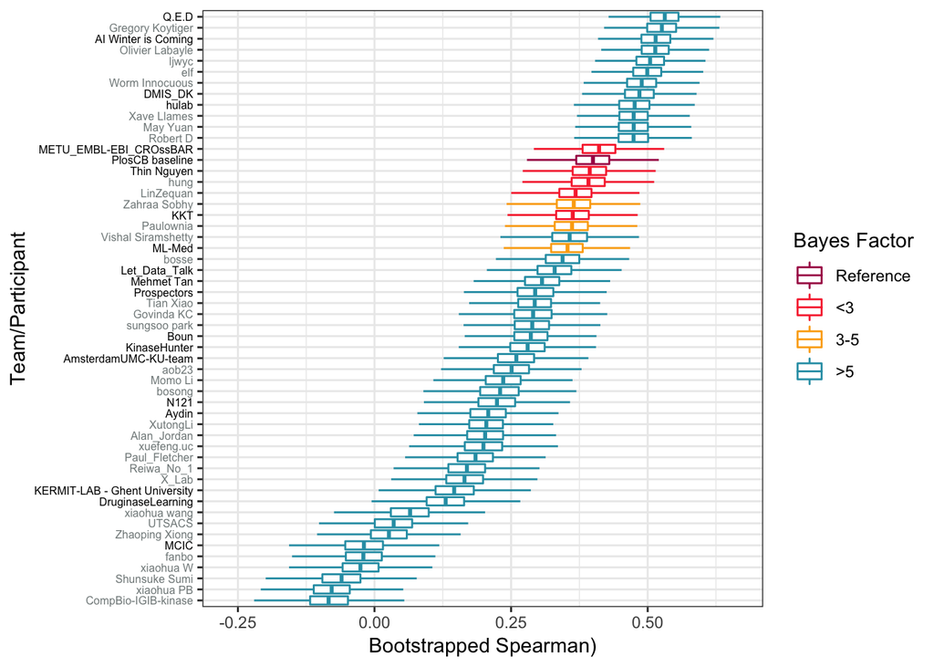

### SC2 - RMSE

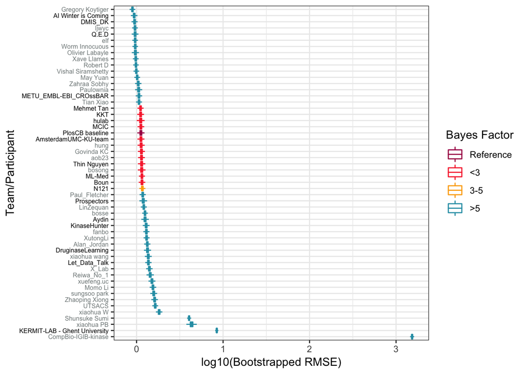